# Descriptive Statistics for Tidy Tuesday Alt Text Project

Silvia P. Canelón, Elizabeth Hare

2021-03-14

# Summary: How many TidyTuesday posts have alt text?

Silvia scraped 6443 TidyTuesday Tweets posted between 2018 and 2021. I concatenated them into one data set. The four categories for the alt text field were

1. Default Description - Twitter fills in “Image”
2. Descriptive Text - the user supplied alt-text
3. Scraping Error - the alt text could not be retrieved
4. Alt-text unavailable due to non-static content

| **Characteristic** | **AltTextCat** DefaultDescription | **AltTextCat** DescriptiveText | **AltTextCat** ScrapingError | **AltTextCat** UnavailableNonStatic | **Total** |  |
| --- | --- | --- | --- | --- | --- | --- |
| Year |  |  |  |  |  |  |
| 2018 | 565 (80%) | 8 (1.1%) | 64 (9.0%) | 72 (10%) | 709 (100%) |  |
| 2019 | 1,663 (82%) | 21 (1.0%) | 79 (3.9%) | 259 (13%) | 2,022 (100%) |  |
| 2020 | 2,861 (85%) | 99 (2.9%) | 105 (3.1%) | 309 (9.2%) | 3,374 (100%) |  |
| 2021 | 302 (89%) | 26 (7.7%) | 1 (0.3%) | 9 (2.7%) | 338 (100%) |  |
| Total | 5,391 (84%) | 154 (2.4%) | 249 (3.9%) | 649 (10%) | 6,443 (100%) |  |

# Word and character counts

## Words

| **Characteristic** | **2018**, N = 8<sup>1</sup> | **2019**, N = 21<sup>1</sup> | **2020**, N = 99<sup>1</sup> | **2021**, N = 26<sup>1</sup> |
| --- | --- | --- | --- | --- |
| wordCount | 37, 9-68 | 20, 2-68 | 16, 1-170 | 22, 2-109 |

<sup>*1*</sup> Statistics presented: Median, Minimum-Maximum

## Characters

The maximum character count for Twitter alt-text is 420. The median character count for all years is 93, with a range of 8 to 788. The following table provides these statistics by year:

[output not shown]

<sup>*1*</sup> Statistics presented: Median, Minimum-Maximum

# Tweets Per Week

As estimates of how many people we can get to participate in a week, let’s look at 2021 so far.

| Week | Count |
| --- | --- |
| 1 | 59 |
| 2 | 55 |
| 3 | 112 |
| 4 | 91 |
| 5 | 21 |

To get an idea of the best time of year, we look at the last 13 months of data, a bar chart for the eyeball people and a table for me.

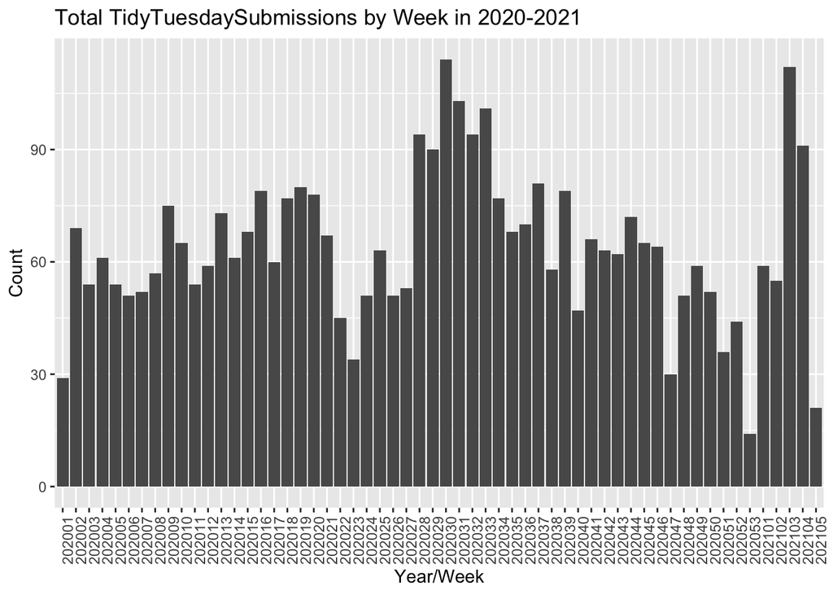

| **Characteristic** | **Year** 2020 | **Year** 2021 | **Total** |  |
| --- | --- | --- | --- | --- |
| wk |  |  |  |  |
| 1 | 29 | 59 | 88 |  |
| 2 | 69 | 55 | 124 |  |
| 3 | 54 | 112 | 166 |  |
| 4 | 61 | 91 | 152 |  |
| 5 | 54 | 21 | 75 |  |
| 6 | 51 | 0 | 51 |  |
| 7 | 52 | 0 | 52 |  |
| 8 | 57 | 0 | 57 |  |
| 9 | 75 | 0 | 75 |  |
| 10 | 65 | 0 | 65 |  |
| 11 | 54 | 0 | 54 |  |
| 12 | 59 | 0 | 59 |  |
| 13 | 73 | 0 | 73 |  |
| 14 | 61 | 0 | 61 |  |
| 15 | 68 | 0 | 68 |  |
| 16 | 79 | 0 | 79 |  |
| 17 | 60 | 0 | 60 |  |
| 18 | 77 | 0 | 77 |  |
| 19 | 80 | 0 | 80 |  |
| 20 | 78 | 0 | 78 |  |
| 21 | 67 | 0 | 67 |  |
| 22 | 45 | 0 | 45 |  |
| 23 | 34 | 0 | 34 |  |
| 24 | 51 | 0 | 51 |  |
| 25 | 63 | 0 | 63 |  |
| 26 | 51 | 0 | 51 |  |
| 27 | 53 | 0 | 53 |  |
| 28 | 94 | 0 | 94 |  |
| 29 | 90 | 0 | 90 |  |
| 30 | 114 | 0 | 114 |  |
| 31 | 103 | 0 | 103 |  |
| 32 | 94 | 0 | 94 |  |
| 33 | 101 | 0 | 101 |  |
| 34 | 77 | 0 | 77 |  |
| 35 | 68 | 0 | 68 |  |
| 36 | 70 | 0 | 70 |  |
| 37 | 81 | 0 | 81 |  |
| 38 | 58 | 0 | 58 |  |
| 39 | 79 | 0 | 79 |  |
| 40 | 47 | 0 | 47 |  |
| 41 | 66 | 0 | 66 |  |
| 42 | 63 | 0 | 63 |  |
| 43 | 62 | 0 | 62 |  |
| 44 | 72 | 0 | 72 |  |
| 45 | 65 | 0 | 65 |  |
| 46 | 64 | 0 | 64 |  |
| 47 | 30 | 0 | 30 |  |
| 48 | 51 | 0 | 51 |  |
| 49 | 59 | 0 | 59 |  |
| 50 | 52 | 0 | 52 |  |
| 51 | 36 | 0 | 36 |  |
| 52 | 44 | 0 | 44 |  |
| 53 | 14 | 0 | 14 |  |
| Total | 3,374 | 338 | 3,712 |  |